# Test a Perceptual Phenomenon

### Analyzing the Stroop Effect

Perform the analysis in the space below. Remember to follow [the instructions](https://docs.google.com/document/d/1-OkpZLjG_kX9J6LIQ5IltsqMzVWjh36QpnP2RYpVdPU/pub?embedded=True) and review the [project rubric](https://review.udacity.com/#!/rubrics/71/view) before submitting. Once you've completed the analysis and write-up, download this file as a PDF or HTML file, upload that PDF/HTML into the workspace here (click on the orange Jupyter icon in the upper left then Upload), then use the Submit Project button at the bottom of this page. This will create a zip file containing both this .ipynb doc and the PDF/HTML doc that will be submitted for your project.

(1) What is the independent variable? What is the dependent variable?

1-independent variable: **Congruent,Incongruent**

2-dependent variable: **The response time to pronounce the color**

(2) What is an appropriate set of hypotheses for this task? Specify your null and alternative hypotheses, and clearly define any notation used. Justify your choices.

**1- H0 (Null Hypothesis)**

There is no difference in response time between incongruent and congruent.

**H0: (μC - μI)=0**

**2- H1 (Alternate Hypothesis)**

The response time of the incongruent will not be equal the the response time of the congruent.

**H0: (μC - μI)!=0**

(3) Report some descriptive statistics regarding this dataset. Include at least one measure of central tendency and at least one measure of variability. The name of the data file is 'stroopdata.csv'.

```python
import matplotlib.pyplot as plt
import pandas as pd
import numpy as np
import seaborn as sns
import scipy.stats as st

df = pd.read_csv("stroopdata.csv")
```

```python
df.head(60)
```

|  | Congruent | Incongruent |
| --- | --- | --- |
| 0 | 12.079 | 19.278 |
| 1 | 16.791 | 18.741 |
| 2 | 9.564 | 21.214 |
| 3 | 8.630 | 15.687 |
| 4 | 14.669 | 22.803 |
| 5 | 12.238 | 20.878 |
| 6 | 14.692 | 24.572 |
| 7 | 8.987 | 17.394 |
| 8 | 9.401 | 20.762 |
| 9 | 14.480 | 26.282 |
| 10 | 22.328 | 24.524 |
| 11 | 15.298 | 18.644 |
| 12 | 15.073 | 17.510 |
| 13 | 16.929 | 20.330 |
| 14 | 18.200 | 35.255 |
| 15 | 12.130 | 22.158 |
| 16 | 18.495 | 25.139 |
| 17 | 10.639 | 20.429 |
| 18 | 11.344 | 17.425 |
| 19 | 12.369 | 34.288 |
| 20 | 12.944 | 23.894 |
| 21 | 14.233 | 17.960 |
| 22 | 19.710 | 22.058 |
| 23 | 16.004 | 21.157 |

```python
df.describe()
```

|  | Congruent | Incongruent |
| --- | --- | --- |
| count | 24.000000 | 24.000000 |
| mean | 14.051125 | 22.015917 |
| std | 3.559358 | 4.797057 |
| min | 8.630000 | 15.687000 |
| 25% | 11.895250 | 18.716750 |
| 50% | 14.356500 | 21.017500 |
| 75% | 16.200750 | 24.051500 |
| max | 22.328000 | 35.255000 |

**If the size of the samples was big then we would've used the (z test)**

```python
congruent_mean = df['Congruent'].mean()
incongruent_mean = df['Incongruent'].mean()
print("the mean of the Congruent is: ")
print(congruent_mean)
print("the mean of the Incongruent is: ")
print(incongruent_mean)
```

```
the mean of the Congruent is:
14.051125
the mean of the Incongruent is:
22.0159166667
```

```python
congruent_std = df['Congruent'].std()
incongruent_std = df['Incongruent'].std()
print("the standard deviation of the Congruent is:")
print(congruent_std)
print("the standard deviation of the Incongruent is:")
print(incongruent_std)
```

```
the standard deviation of the Congruent is:
3.55935795765
the standard deviation of the Incongruent is:
4.79705712247
```

```python
print("the standard deviation for Congruent: {0:.5f}".format(np.std(df['Congruent'].values)))
print("the standard deviation for Incongruent: {0:.5f}".format(np.std(df['Incongruent'].values)))
```

```
the standard deviation for Congruent: 3.48442
the standard deviation for Incongruent: 4.69606
```

(4) Provide one or two visualizations that show the distribution of the sample data. Write one or two sentences noting what you observe about the plot or plots.

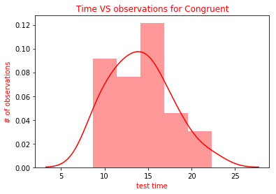

```python
a=sns.distplot( df["Congruent"],color='r')
plt.xlabel('test time',color='r')
plt.ylabel('# of observations',color='r')
plt.title('Time VS observations for Congruent',color='r');
```

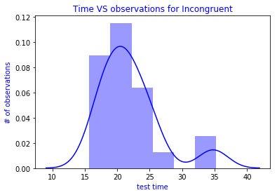

```python
a=sns.distplot( df["Incongruent"],color='b')
plt.xlabel('test time',color='b')
plt.ylabel('# of observations',color='b')
plt.title('Time VS observations for Incongruent',color='b');
```

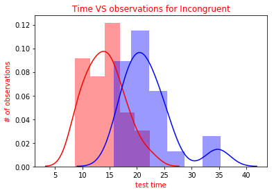

```python
sns.distplot( df["Congruent"],color='r')

plt.xlabel('test time',color='r')
plt.ylabel('# of observations',color='r')
plt.title('Time VS observations for Congruent',color='r');


sns.distplot( df["Incongruent"],color='b')

plt.xlabel('test time',color='r')
plt.ylabel('# of observations',color='r')
plt.title('Time VS observations for Incongruent',color='r');
```

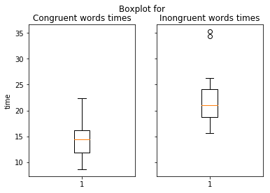

```python
x = df['Congruent']
y = df['Incongruent']


f, (Congruent, Inongruent) = plt.subplots(1, 2, sharey=True)
f.suptitle('Boxplot for')

Congruent.boxplot(x)
Congruent.set_title('Congruent words times')
Congruent.set_ylabel('time')

Inongruent.boxplot(y)
Inongruent.set_title('Inongruent words times')

plt.show()
```

(5) Now, perform the statistical test and report your results. What is your confidence level or Type I error associated with your test? What is your conclusion regarding the hypotheses you set up? Did the results match up with your expectations? **Hint:** Think about what is being measured on each individual, and what statistic best captures how an individual reacts in each environment.

```python
t,p = st.ttest_rel(df['Incongruent'],df['Congruent'],axis=0)

print(t)

print(p)

alpha = 0.005
```

```
8.02070694411
4.10300058571e-08
```

**degrees of freedom = 23**

**calculated t-value = 8.02**

**p-value = 0.00000004**

(6) Optional: What do you think is responsible for the effects observed? Can you think of an alternative or similar task that would result in a similar effect? Some research about the problem will be helpful for thinking about these two questions!

**Refrences**

- [scipy-lectures](https://www.scipy-lectures.org/packages/statistics/index.html).
- [users.sussex.ac.uk](http://users.sussex.ac.uk/~grahamh/RM1web/t-testcriticalvalues.pdf).
- [programiz](https://www.programiz.com/python-programming/methods/string/format).
- [towardsdatascience](https://towardsdatascience.com/inferential-statistics-series-t-test-using-numpy-2718f8f9bf2f).
- [knowledgetack](http://knowledgetack.com/python/statsmodels/proportions_ztest/).